# Optimal Treatment Analysis

## Outcome Variable

**Outcome Variable:** ever_stunted

## Predictor Variables

**Intervention Variable:** birthwt

**Adjustment Set:**

- arm
- sex
- W_mage
- meducyrs
- feducyrs
- vagbrth
- single
- brthmon
- W_parity
- delta_W_mage
- delta_meducyrs
- delta_feducyrs
- delta_vagbrth
- delta_single
- delta_brthmon
- delta_W_parity

## Stratifying Variables

The analysis was stratified on these variable(s):

- agecat
- studyid
- country

## Data Summary

| agecat | studyid | country | birthwt | ever_stunted | n_cell | n |
| --- | --- | --- | --- | --- | --- | --- |
| 0-24 months (no birth st.) | ki0047075b-MAL-ED | BANGLADESH | Normal or high birthweight | 0 | 92 | 212 |
| 0-24 months (no birth st.) | ki0047075b-MAL-ED | BANGLADESH | Normal or high birthweight | 1 | 96 | 212 |
| 0-24 months (no birth st.) | ki0047075b-MAL-ED | BANGLADESH | Low birth weight | 0 | 9 | 212 |
| 0-24 months (no birth st.) | ki0047075b-MAL-ED | BANGLADESH | Low birth weight | 1 | 15 | 212 |
| 0-24 months (no birth st.) | ki0047075b-MAL-ED | BRAZIL | Normal or high birthweight | 0 | 176 | 208 |
| 0-24 months (no birth st.) | ki0047075b-MAL-ED | BRAZIL | Normal or high birthweight | 1 | 29 | 208 |
| 0-24 months (no birth st.) | ki0047075b-MAL-ED | BRAZIL | Low birth weight | 0 | 3 | 208 |
| 0-24 months (no birth st.) | ki0047075b-MAL-ED | BRAZIL | Low birth weight | 1 | 0 | 208 |
| 0-24 months (no birth st.) | ki0047075b-MAL-ED | INDIA | Normal or high birthweight | 0 | 87 | 205 |
| 0-24 months (no birth st.) | ki0047075b-MAL-ED | INDIA | Normal or high birthweight | 1 | 97 | 205 |
| 0-24 months (no birth st.) | ki0047075b-MAL-ED | INDIA | Low birth weight | 0 | 11 | 205 |
| 0-24 months (no birth st.) | ki0047075b-MAL-ED | INDIA | Low birth weight | 1 | 10 | 205 |
| 0-24 months (no birth st.) | ki0047075b-MAL-ED | NEPAL | Normal or high birthweight | 0 | 151 | 206 |
| 0-24 months (no birth st.) | ki0047075b-MAL-ED | NEPAL | Normal or high birthweight | 1 | 47 | 206 |
| 0-24 months (no birth st.) | ki0047075b-MAL-ED | NEPAL | Low birth weight | 0 | 5 | 206 |
| 0-24 months (no birth st.) | ki0047075b-MAL-ED | NEPAL | Low birth weight | 1 | 3 | 206 |
| 0-24 months (no birth st.) | ki0047075b-MAL-ED | PERU | Normal or high birthweight | 0 | 114 | 264 |
| 0-24 months (no birth st.) | ki0047075b-MAL-ED | PERU | Normal or high birthweight | 1 | 148 | 264 |
| 0-24 months (no birth st.) | ki0047075b-MAL-ED | PERU | Low birth weight | 0 | 0 | 264 |
| 0-24 months (no birth st.) | ki0047075b-MAL-ED | PERU | Low birth weight | 1 | 2 | 264 |
| 0-24 months (no birth st.) | ki0047075b-MAL-ED | SOUTH AFRICA | Normal or high birthweight | 0 | 140 | 280 |
| 0-24 months (no birth st.) | ki0047075b-MAL-ED | SOUTH AFRICA | Normal or high birthweight | 1 | 130 | 280 |
| 0-24 months (no birth st.) | ki0047075b-MAL-ED | SOUTH AFRICA | Low birth weight | 0 | 3 | 280 |
| 0-24 months (no birth st.) | ki0047075b-MAL-ED | SOUTH AFRICA | Low birth weight | 1 | 7 | 280 |
| 0-24 months (no birth st.) | ki0047075b-MAL-ED | TANZANIA, UNITED REPUBLIC OF | Normal or high birthweight | 0 | 27 | 116 |
| 0-24 months (no birth st.) | ki0047075b-MAL-ED | TANZANIA, UNITED REPUBLIC OF | Normal or high birthweight | 1 | 88 | 116 |
| 0-24 months (no birth st.) | ki0047075b-MAL-ED | TANZANIA, UNITED REPUBLIC OF | Low birth weight | 0 | 1 | 116 |
| 0-24 months (no birth st.) | ki0047075b-MAL-ED | TANZANIA, UNITED REPUBLIC OF | Low birth weight | 1 | 0 | 116 |
| 0-24 months (no birth st.) | ki1000108-CMC-V-BCS-2002 | INDIA | Normal or high birthweight | 0 | 27 | 296 |
| 0-24 months (no birth st.) | ki1000108-CMC-V-BCS-2002 | INDIA | Normal or high birthweight | 1 | 255 | 296 |

[output cut: 314 more lines]

The following strata were considered:

- agecat: 0-24 months (no birth st.), studyid: ki0047075b-MAL-ED, country: BANGLADESH
- agecat: 0-24 months (no birth st.), studyid: ki0047075b-MAL-ED, country: BRAZIL
- agecat: 0-24 months (no birth st.), studyid: ki0047075b-MAL-ED, country: INDIA
- agecat: 0-24 months (no birth st.), studyid: ki0047075b-MAL-ED, country: NEPAL
- agecat: 0-24 months (no birth st.), studyid: ki0047075b-MAL-ED, country: PERU
- agecat: 0-24 months (no birth st.), studyid: ki0047075b-MAL-ED, country: SOUTH AFRICA
- agecat: 0-24 months (no birth st.), studyid: ki0047075b-MAL-ED, country: TANZANIA, UNITED REPUBLIC OF
- agecat: 0-24 months (no birth st.), studyid: ki1000108-CMC-V-BCS-2002, country: INDIA
- agecat: 0-24 months (no birth st.), studyid: ki1000108-IRC, country: INDIA
- agecat: 0-24 months (no birth st.), studyid: ki1000109-EE, country: PAKISTAN
- agecat: 0-24 months (no birth st.), studyid: ki1000109-ResPak, country: PAKISTAN
- agecat: 0-24 months (no birth st.), studyid: ki1000304b-SAS-CompFeed, country: INDIA
- agecat: 0-24 months (no birth st.), studyid: ki1017093-NIH-Birth, country: BANGLADESH
- agecat: 0-24 months (no birth st.), studyid: ki1017093b-PROVIDE, country: BANGLADESH
- agecat: 0-24 months (no birth st.), studyid: ki1017093c-NIH-Crypto, country: BANGLADESH
- agecat: 0-24 months (no birth st.), studyid: ki1066203-TanzaniaChild2, country: TANZANIA, UNITED REPUBLIC OF
- agecat: 0-24 months (no birth st.), studyid: ki1101329-Keneba, country: GAMBIA
- agecat: 0-24 months (no birth st.), studyid: ki1114097-CMIN, country: BANGLADESH
- agecat: 0-24 months (no birth st.), studyid: ki1114097-CMIN, country: BRAZIL
- agecat: 0-24 months (no birth st.), studyid: ki1114097-CMIN, country: GUINEA-BISSAU
- agecat: 0-24 months (no birth st.), studyid: ki1114097-CMIN, country: PERU
- agecat: 0-24 months (no birth st.), studyid: ki1114097-CONTENT, country: PERU
- agecat: 0-24 months (no birth st.), studyid: ki1119695-PROBIT, country: BELARUS
- agecat: 0-24 months (no birth st.), studyid: ki1126311-ZVITAMBO, country: ZIMBABWE
- agecat: 0-24 months (no birth st.), studyid: ki1135781-COHORTS, country: GUATEMALA
- agecat: 0-24 months (no birth st.), studyid: ki1135781-COHORTS, country: INDIA
- agecat: 0-24 months (no birth st.), studyid: ki1135781-COHORTS, country: PHILIPPINES
- agecat: 0-24 months (no birth st.), studyid: kiGH5241-JiVitA-3, country: BANGLADESH
- agecat: 0-24 months (no birth st.), studyid: kiGH5241-JiVitA-4, country: BANGLADESH
- agecat: 0-6 months (no birth st.), studyid: ki0047075b-MAL-ED, country: BANGLADESH
- agecat: 0-6 months (no birth st.), studyid: ki0047075b-MAL-ED, country: BRAZIL
- agecat: 0-6 months (no birth st.), studyid: ki0047075b-MAL-ED, country: INDIA
- agecat: 0-6 months (no birth st.), studyid: ki0047075b-MAL-ED, country: NEPAL
- agecat: 0-6 months (no birth st.), studyid: ki0047075b-MAL-ED, country: PERU
- agecat: 0-6 months (no birth st.), studyid: ki0047075b-MAL-ED, country: SOUTH AFRICA
- agecat: 0-6 months (no birth st.), studyid: ki0047075b-MAL-ED, country: TANZANIA, UNITED REPUBLIC OF
- agecat: 0-6 months (no birth st.), studyid: ki1000108-CMC-V-BCS-2002, country: INDIA
- agecat: 0-6 months (no birth st.), studyid: ki1000108-IRC, country: INDIA
- agecat: 0-6 months (no birth st.), studyid: ki1000109-EE, country: PAKISTAN
- agecat: 0-6 months (no birth st.), studyid: ki1000109-ResPak, country: PAKISTAN
- agecat: 0-6 months (no birth st.), studyid: ki1000304b-SAS-CompFeed, country: INDIA
- agecat: 0-6 months (no birth st.), studyid: ki1017093-NIH-Birth, country: BANGLADESH
- agecat: 0-6 months (no birth st.), studyid: ki1017093b-PROVIDE, country: BANGLADESH
- agecat: 0-6 months (no birth st.), studyid: ki1017093c-NIH-Crypto, country: BANGLADESH
- agecat: 0-6 months (no birth st.), studyid: ki1066203-TanzaniaChild2, country: TANZANIA, UNITED REPUBLIC OF
- agecat: 0-6 months (no birth st.), studyid: ki1101329-Keneba, country: GAMBIA
- agecat: 0-6 months (no birth st.), studyid: ki1114097-CMIN, country: BANGLADESH
- agecat: 0-6 months (no birth st.), studyid: ki1114097-CMIN, country: BRAZIL
- agecat: 0-6 months (no birth st.), studyid: ki1114097-CMIN, country: GUINEA-BISSAU
- agecat: 0-6 months (no birth st.), studyid: ki1114097-CMIN, country: PERU
- agecat: 0-6 months (no birth st.), studyid: ki1114097-CONTENT, country: PERU
- agecat: 0-6 months (no birth st.), studyid: ki1119695-PROBIT, country: BELARUS
- agecat: 0-6 months (no birth st.), studyid: ki1126311-ZVITAMBO, country: ZIMBABWE
- agecat: 0-6 months (no birth st.), studyid: ki1135781-COHORTS, country: GUATEMALA
- agecat: 0-6 months (no birth st.), studyid: ki1135781-COHORTS, country: INDIA
- agecat: 0-6 months (no birth st.), studyid: ki1135781-COHORTS, country: PHILIPPINES
- agecat: 0-6 months (no birth st.), studyid: kiGH5241-JiVitA-3, country: BANGLADESH
- agecat: 0-6 months (no birth st.), studyid: kiGH5241-JiVitA-4, country: BANGLADESH
- agecat: 6-24 months, studyid: ki0047075b-MAL-ED, country: BANGLADESH
- agecat: 6-24 months, studyid: ki0047075b-MAL-ED, country: BRAZIL
- agecat: 6-24 months, studyid: ki0047075b-MAL-ED, country: INDIA
- agecat: 6-24 months, studyid: ki0047075b-MAL-ED, country: NEPAL
- agecat: 6-24 months, studyid: ki0047075b-MAL-ED, country: PERU
- agecat: 6-24 months, studyid: ki0047075b-MAL-ED, country: SOUTH AFRICA
- agecat: 6-24 months, studyid: ki0047075b-MAL-ED, country: TANZANIA, UNITED REPUBLIC OF
- agecat: 6-24 months, studyid: ki1000108-CMC-V-BCS-2002, country: INDIA
- agecat: 6-24 months, studyid: ki1000108-IRC, country: INDIA
- agecat: 6-24 months, studyid: ki1000109-EE, country: PAKISTAN
- agecat: 6-24 months, studyid: ki1000109-ResPak, country: PAKISTAN
- agecat: 6-24 months, studyid: ki1000304b-SAS-CompFeed, country: INDIA
- agecat: 6-24 months, studyid: ki1017093-NIH-Birth, country: BANGLADESH
- agecat: 6-24 months, studyid: ki1017093b-PROVIDE, country: BANGLADESH
- agecat: 6-24 months, studyid: ki1017093c-NIH-Crypto, country: BANGLADESH
- agecat: 6-24 months, studyid: ki1066203-TanzaniaChild2, country: TANZANIA, UNITED REPUBLIC OF
- agecat: 6-24 months, studyid: ki1101329-Keneba, country: GAMBIA
- agecat: 6-24 months, studyid: ki1114097-CMIN, country: BRAZIL
- agecat: 6-24 months, studyid: ki1114097-CMIN, country: GUINEA-BISSAU
- agecat: 6-24 months, studyid: ki1114097-CMIN, country: PERU
- agecat: 6-24 months, studyid: ki1114097-CONTENT, country: PERU
- agecat: 6-24 months, studyid: ki1119695-PROBIT, country: BELARUS
- agecat: 6-24 months, studyid: ki1126311-ZVITAMBO, country: ZIMBABWE
- agecat: 6-24 months, studyid: ki1135781-COHORTS, country: GUATEMALA
- agecat: 6-24 months, studyid: ki1135781-COHORTS, country: INDIA
- agecat: 6-24 months, studyid: ki1135781-COHORTS, country: PHILIPPINES
- agecat: 6-24 months, studyid: kiGH5241-JiVitA-3, country: BANGLADESH
- agecat: 6-24 months, studyid: kiGH5241-JiVitA-4, country: BANGLADESH

### Dropped Strata

Some strata were dropped due to rare outcomes:

- agecat: 0-24 months (no birth st.), studyid: ki0047075b-MAL-ED, country: BRAZIL
- agecat: 0-24 months (no birth st.), studyid: ki0047075b-MAL-ED, country: NEPAL
- agecat: 0-24 months (no birth st.), studyid: ki0047075b-MAL-ED, country: PERU
- agecat: 0-24 months (no birth st.), studyid: ki0047075b-MAL-ED, country: SOUTH AFRICA
- agecat: 0-24 months (no birth st.), studyid: ki0047075b-MAL-ED, country: TANZANIA, UNITED REPUBLIC OF
- agecat: 0-24 months (no birth st.), studyid: ki1000108-CMC-V-BCS-2002, country: INDIA
- agecat: 0-24 months (no birth st.), studyid: ki1000109-EE, country: PAKISTAN
- agecat: 0-24 months (no birth st.), studyid: ki1000109-ResPak, country: PAKISTAN
- agecat: 0-24 months (no birth st.), studyid: ki1114097-CMIN, country: BANGLADESH
- agecat: 0-24 months (no birth st.), studyid: ki1114097-CMIN, country: BRAZIL
- agecat: 0-24 months (no birth st.), studyid: ki1114097-CMIN, country: GUINEA-BISSAU
- agecat: 0-24 months (no birth st.), studyid: ki1114097-CMIN, country: PERU
- agecat: 0-24 months (no birth st.), studyid: ki1114097-CONTENT, country: PERU
- agecat: 0-24 months (no birth st.), studyid: ki1119695-PROBIT, country: BELARUS
- agecat: 0-6 months (no birth st.), studyid: ki0047075b-MAL-ED, country: BRAZIL
- agecat: 0-6 months (no birth st.), studyid: ki0047075b-MAL-ED, country: NEPAL
- agecat: 0-6 months (no birth st.), studyid: ki0047075b-MAL-ED, country: PERU
- agecat: 0-6 months (no birth st.), studyid: ki0047075b-MAL-ED, country: SOUTH AFRICA
- agecat: 0-6 months (no birth st.), studyid: ki0047075b-MAL-ED, country: TANZANIA, UNITED REPUBLIC OF
- agecat: 0-6 months (no birth st.), studyid: ki1000108-CMC-V-BCS-2002, country: INDIA
- agecat: 0-6 months (no birth st.), studyid: ki1000109-ResPak, country: PAKISTAN
- agecat: 0-6 months (no birth st.), studyid: ki1114097-CMIN, country: BANGLADESH
- agecat: 0-6 months (no birth st.), studyid: ki1114097-CMIN, country: BRAZIL
- agecat: 0-6 months (no birth st.), studyid: ki1114097-CMIN, country: GUINEA-BISSAU
- agecat: 0-6 months (no birth st.), studyid: ki1114097-CMIN, country: PERU
- agecat: 0-6 months (no birth st.), studyid: ki1114097-CONTENT, country: PERU
- agecat: 0-6 months (no birth st.), studyid: ki1119695-PROBIT, country: BELARUS
- agecat: 6-24 months, studyid: ki0047075b-MAL-ED, country: BANGLADESH
- agecat: 6-24 months, studyid: ki0047075b-MAL-ED, country: BRAZIL
- agecat: 6-24 months, studyid: ki0047075b-MAL-ED, country: NEPAL
- agecat: 6-24 months, studyid: ki0047075b-MAL-ED, country: PERU
- agecat: 6-24 months, studyid: ki0047075b-MAL-ED, country: SOUTH AFRICA
- agecat: 6-24 months, studyid: ki0047075b-MAL-ED, country: TANZANIA, UNITED REPUBLIC OF
- agecat: 6-24 months, studyid: ki1000108-CMC-V-BCS-2002, country: INDIA
- agecat: 6-24 months, studyid: ki1000109-EE, country: PAKISTAN
- agecat: 6-24 months, studyid: ki1000109-ResPak, country: PAKISTAN
- agecat: 6-24 months, studyid: ki1114097-CMIN, country: BRAZIL
- agecat: 6-24 months, studyid: ki1114097-CMIN, country: GUINEA-BISSAU
- agecat: 6-24 months, studyid: ki1114097-CMIN, country: PERU
- agecat: 6-24 months, studyid: ki1114097-CONTENT, country: PERU
- agecat: 6-24 months, studyid: ki1119695-PROBIT, country: BELARUS
- agecat: 6-24 months, studyid: ki1135781-COHORTS, country: GUATEMALA

## Methods Detail

We’re interested in the causal parameters $E[Y_a]$ for all values of $a \in \mathcal{A}$. These parameters represent the mean outcome if, possibly contrary to fact, we intervened to set all units to have $A=a$. Under the randomization and positivity assumptions, these are identified by the statistical parameters $\psi_a=E_W[E_{Y|A,W}(Y|A=a,W)]$. In addition, we’re interested in the mean of $Y$, $E[Y]$ under no intervention (the observed mean). We will estimate these parameters by using SuperLearner to fit the relevant likelihood factors – $E_{Y|A,W}(Y|A=a,W)$ and $p(A=a|W)$, and then updating our likelihood fit using a joint TMLE.

For unadjusted analyses ($W=\{\}$), initial likelihoods were estimated using Lrnr_glm to estimate the simple $E(Y|A)$ and Lrnr_mean to estimate $p(A)$. For adjusted analyses, a small library containing Lrnr_glmnet, Lrnr_xgboost, and Lrnr_mean was used.

Having estimated these parameters, we will then use the delta method to estimate relative risks and attributable risks relative to a prespecified baseline level of $A$.

# Results Detail

## Results Plots

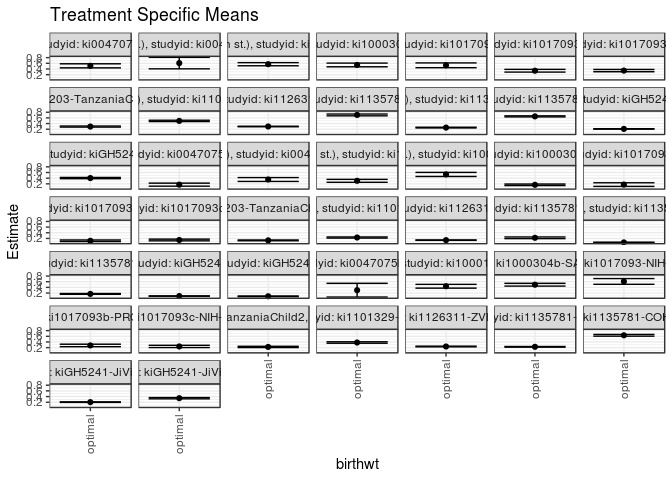

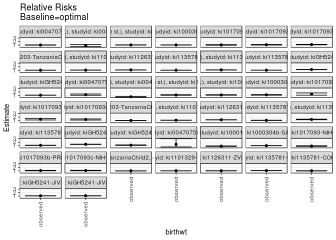

## Results Table

### Parameter: TSM

| agecat | studyid | country | intervention_level | baseline_level | estimate | ci_lower | ci_upper |
| --- | --- | --- | --- | --- | --- | --- | --- |
| 0-24 months (no birth st.) | ki0047075b-MAL-ED | BANGLADESH | optimal | NA | 0.5110930 | 0.4393951 | 0.5827909 |
| 0-24 months (no birth st.) | ki0047075b-MAL-ED | INDIA | optimal | NA | 0.6072205 | 0.4052999 | 0.8091412 |
| 0-24 months (no birth st.) | ki1000108-IRC | INDIA | optimal | NA | 0.5687755 | 0.5135261 | 0.6240250 |
| 0-24 months (no birth st.) | ki1000304b-SAS-CompFeed | INDIA | optimal | NA | 0.5426039 | 0.4771546 | 0.6080531 |
| 0-24 months (no birth st.) | ki1017093-NIH-Birth | BANGLADESH | optimal | NA | 0.5297541 | 0.4454893 | 0.6140188 |
| 0-24 months (no birth st.) | ki1017093b-PROVIDE | BANGLADESH | optimal | NA | 0.3385761 | 0.2908394 | 0.3863127 |
| 0-24 months (no birth st.) | ki1017093c-NIH-Crypto | BANGLADESH | optimal | NA | 0.3429942 | 0.3028581 | 0.3831302 |
| 0-24 months (no birth st.) | ki1066203-TanzaniaChild2 | TANZANIA, UNITED REPUBLIC OF | optimal | NA | 0.2948093 | 0.2754681 | 0.3141504 |
| 0-24 months (no birth st.) | ki1101329-Keneba | GAMBIA | optimal | NA | 0.4942575 | 0.4711628 | 0.5173522 |
| 0-24 months (no birth st.) | ki1126311-ZVITAMBO | ZIMBABWE | optimal | NA | 0.2971982 | 0.2887968 | 0.3055995 |
| 0-24 months (no birth st.) | ki1135781-COHORTS | GUATEMALA | optimal | NA | 0.7051649 | 0.6732841 | 0.7370458 |
| 0-24 months (no birth st.) | ki1135781-COHORTS | INDIA | optimal | NA | 0.2579899 | 0.2460589 | 0.2699209 |
| 0-24 months (no birth st.) | ki1135781-COHORTS | PHILIPPINES | optimal | NA | 0.6537236 | 0.6356222 | 0.6718250 |
| 0-24 months (no birth st.) | kiGH5241-JiVitA-3 | BANGLADESH | optimal | NA | 0.2120402 | 0.2041152 | 0.2199652 |
| 0-24 months (no birth st.) | kiGH5241-JiVitA-4 | BANGLADESH | optimal | NA | 0.4038015 | 0.3813059 | 0.4262972 |
| 0-6 months (no birth st.) | ki0047075b-MAL-ED | BANGLADESH | optimal | NA | 0.1713060 | 0.1175466 | 0.2250653 |
| 0-6 months (no birth st.) | ki0047075b-MAL-ED | INDIA | optimal | NA | 0.3531074 | 0.2847223 | 0.4214925 |
| 0-6 months (no birth st.) | ki1000108-IRC | INDIA | optimal | NA | 0.3068559 | 0.2552696 | 0.3584421 |
| 0-6 months (no birth st.) | ki1000109-EE | PAKISTAN | optimal | NA | 0.5317888 | 0.4598249 | 0.6037527 |
| 0-6 months (no birth st.) | ki1000304b-SAS-CompFeed | INDIA | optimal | NA | 0.1658644 | 0.1393959 | 0.1923329 |
| 0-6 months (no birth st.) | ki1017093-NIH-Birth | BANGLADESH | optimal | NA | 0.1742066 | 0.1101298 | 0.2382834 |
| 0-6 months (no birth st.) | ki1017093b-PROVIDE | BANGLADESH | optimal | NA | 0.1170917 | 0.0892035 | 0.1449799 |
| 0-6 months (no birth st.) | ki1017093c-NIH-Crypto | BANGLADESH | optimal | NA | 0.1454981 | 0.1156143 | 0.1753819 |
| 0-6 months (no birth st.) | ki1066203-TanzaniaChild2 | TANZANIA, UNITED REPUBLIC OF | optimal | NA | 0.1321526 | 0.1177935 | 0.1465118 |
| 0-6 months (no birth st.) | ki1101329-Keneba | GAMBIA | optimal | NA | 0.2328929 | 0.2130031 | 0.2527827 |
| 0-6 months (no birth st.) | ki1126311-ZVITAMBO | ZIMBABWE | optimal | NA | 0.1400638 | 0.1336213 | 0.1465064 |
| 0-6 months (no birth st.) | ki1135781-COHORTS | GUATEMALA | optimal | NA | 0.2225349 | 0.1930918 | 0.2519779 |
| 0-6 months (no birth st.) | ki1135781-COHORTS | INDIA | optimal | NA | 0.0597172 | 0.0531718 | 0.0662626 |
| 0-6 months (no birth st.) | ki1135781-COHORTS | PHILIPPINES | optimal | NA | 0.1692565 | 0.1549590 | 0.1835539 |
| 0-6 months (no birth st.) | kiGH5241-JiVitA-3 | BANGLADESH | optimal | NA | 0.0939078 | 0.0884387 | 0.0993768 |
| 0-6 months (no birth st.) | kiGH5241-JiVitA-4 | BANGLADESH | optimal | NA | 0.0852316 | 0.0729860 | 0.0974772 |
| 6-24 months | ki0047075b-MAL-ED | INDIA | optimal | NA | 0.3003467 | 0.0589096 | 0.5417838 |
| 6-24 months | ki1000108-IRC | INDIA | optimal | NA | 0.4392868 | 0.3726116 | 0.5059620 |
| 6-24 months | ki1000304b-SAS-CompFeed | INDIA | optimal | NA | 0.4933984 | 0.4452232 | 0.5415737 |
| 6-24 months | ki1017093-NIH-Birth | BANGLADESH | optimal | NA | 0.6082967 | 0.5071494 | 0.7094440 |
| 6-24 months | ki1017093b-PROVIDE | BANGLADESH | optimal | NA | 0.2772477 | 0.2332944 | 0.3212010 |
| 6-24 months | ki1017093c-NIH-Crypto | BANGLADESH | optimal | NA | 0.2415956 | 0.2015676 | 0.2816236 |
| 6-24 months | ki1066203-TanzaniaChild2 | TANZANIA, UNITED REPUBLIC OF | optimal | NA | 0.2246883 | 0.2038123 | 0.2455644 |
| 6-24 months | ki1101329-Keneba | GAMBIA | optimal | NA | 0.3800370 | 0.3544820 | 0.4055920 |
| 6-24 months | ki1126311-ZVITAMBO | ZIMBABWE | optimal | NA | 0.2398564 | 0.2280930 | 0.2516197 |
| 6-24 months | ki1135781-COHORTS | INDIA | optimal | NA | 0.2283432 | 0.2161341 | 0.2405523 |
| 6-24 months | ki1135781-COHORTS | PHILIPPINES | optimal | NA | 0.6348971 | 0.6047512 | 0.6650429 |
| 6-24 months | kiGH5241-JiVitA-3 | BANGLADESH | optimal | NA | 0.2036494 | 0.1935209 | 0.2137779 |
| 6-24 months | kiGH5241-JiVitA-4 | BANGLADESH | optimal | NA | 0.3426005 | 0.3202486 | 0.3649525 |

### Parameter: E(Y)

| agecat | studyid | country | intervention_level | baseline_level | estimate | ci_lower | ci_upper |
| --- | --- | --- | --- | --- | --- | --- | --- |
| 0-24 months (no birth st.) | ki0047075b-MAL-ED | BANGLADESH | observed | NA | 0.5235849 | 0.4561953 | 0.5909746 |
| 0-24 months (no birth st.) | ki0047075b-MAL-ED | INDIA | observed | NA | 0.5219512 | 0.4534049 | 0.5904975 |
| 0-24 months (no birth st.) | ki1000108-IRC | INDIA | observed | NA | 0.5921788 | 0.5412016 | 0.6431559 |
| 0-24 months (no birth st.) | ki1000304b-SAS-CompFeed | INDIA | observed | NA | 0.5661425 | 0.5076572 | 0.6246278 |
| 0-24 months (no birth st.) | ki1017093-NIH-Birth | BANGLADESH | observed | NA | 0.5549451 | 0.4825447 | 0.6273454 |
| 0-24 months (no birth st.) | ki1017093b-PROVIDE | BANGLADESH | observed | NA | 0.3753943 | 0.3376725 | 0.4131162 |
| 0-24 months (no birth st.) | ki1017093c-NIH-Crypto | BANGLADESH | observed | NA | 0.3935681 | 0.3560687 | 0.4310676 |
| 0-24 months (no birth st.) | ki1066203-TanzaniaChild2 | TANZANIA, UNITED REPUBLIC OF | observed | NA | 0.2985075 | 0.2794291 | 0.3175858 |
| 0-24 months (no birth st.) | ki1101329-Keneba | GAMBIA | observed | NA | 0.5129668 | 0.4906500 | 0.5352836 |
| 0-24 months (no birth st.) | ki1126311-ZVITAMBO | ZIMBABWE | observed | NA | 0.3259501 | 0.3177495 | 0.3341508 |
| 0-24 months (no birth st.) | ki1135781-COHORTS | GUATEMALA | observed | NA | 0.7142857 | 0.6835892 | 0.7449822 |
| 0-24 months (no birth st.) | ki1135781-COHORTS | INDIA | observed | NA | 0.2852591 | 0.2737975 | 0.2967207 |
| 0-24 months (no birth st.) | ki1135781-COHORTS | PHILIPPINES | observed | NA | 0.6646643 | 0.6472674 | 0.6820612 |
| 0-24 months (no birth st.) | kiGH5241-JiVitA-3 | BANGLADESH | observed | NA | 0.2540787 | 0.2462528 | 0.2619047 |
| 0-24 months (no birth st.) | kiGH5241-JiVitA-4 | BANGLADESH | observed | NA | 0.4282588 | 0.4077731 | 0.4487445 |
| 0-6 months (no birth st.) | ki0047075b-MAL-ED | BANGLADESH | observed | NA | 0.2075472 | 0.1528264 | 0.2622679 |
| 0-6 months (no birth st.) | ki0047075b-MAL-ED | INDIA | observed | NA | 0.2097561 | 0.1538871 | 0.2656251 |
| 0-6 months (no birth st.) | ki1000108-IRC | INDIA | observed | NA | 0.3435754 | 0.2943128 | 0.3928380 |
| 0-6 months (no birth st.) | ki1000109-EE | PAKISTAN | observed | NA | 0.6024096 | 0.5415000 | 0.6633193 |
| 0-6 months (no birth st.) | ki1000304b-SAS-CompFeed | INDIA | observed | NA | 0.1944444 | 0.1700545 | 0.2188344 |
| 0-6 months (no birth st.) | ki1017093-NIH-Birth | BANGLADESH | observed | NA | 0.2362637 | 0.1743796 | 0.2981478 |
| 0-6 months (no birth st.) | ki1017093b-PROVIDE | BANGLADESH | observed | NA | 0.1593060 | 0.1307970 | 0.1878149 |
| 0-6 months (no birth st.) | ki1017093c-NIH-Crypto | BANGLADESH | observed | NA | 0.1898928 | 0.1597870 | 0.2199986 |
| 0-6 months (no birth st.) | ki1066203-TanzaniaChild2 | TANZANIA, UNITED REPUBLIC OF | observed | NA | 0.1356852 | 0.1214076 | 0.1499628 |
| 0-6 months (no birth st.) | ki1101329-Keneba | GAMBIA | observed | NA | 0.2546652 | 0.2346549 | 0.2746755 |
| 0-6 months (no birth st.) | ki1126311-ZVITAMBO | ZIMBABWE | observed | NA | 0.1709340 | 0.1643442 | 0.1775239 |
| 0-6 months (no birth st.) | ki1135781-COHORTS | GUATEMALA | observed | NA | 0.2371007 | 0.2078658 | 0.2663357 |
| 0-6 months (no birth st.) | ki1135781-COHORTS | INDIA | observed | NA | 0.0788439 | 0.0719356 | 0.0857521 |
| 0-6 months (no birth st.) | ki1135781-COHORTS | PHILIPPINES | observed | NA | 0.1886926 | 0.1742747 | 0.2031105 |
| 0-6 months (no birth st.) | kiGH5241-JiVitA-3 | BANGLADESH | observed | NA | 0.1313499 | 0.1257126 | 0.1369873 |
| 0-6 months (no birth st.) | kiGH5241-JiVitA-4 | BANGLADESH | observed | NA | 0.0979962 | 0.0852560 | 0.1107365 |
| 6-24 months | ki0047075b-MAL-ED | INDIA | observed | NA | 0.4183007 | 0.3398819 | 0.4967194 |
| 6-24 months | ki1000108-IRC | INDIA | observed | NA | 0.3787234 | 0.3165730 | 0.4408738 |
| 6-24 months | ki1000304b-SAS-CompFeed | INDIA | observed | NA | 0.5018680 | 0.4570583 | 0.5466777 |
| 6-24 months | ki1017093-NIH-Birth | BANGLADESH | observed | NA | 0.5471698 | 0.4519599 | 0.6423797 |
| 6-24 months | ki1017093b-PROVIDE | BANGLADESH | observed | NA | 0.2997812 | 0.2577294 | 0.3418330 |
| 6-24 months | ki1017093c-NIH-Crypto | BANGLADESH | observed | NA | 0.2628458 | 0.2244546 | 0.3012371 |
| 6-24 months | ki1066203-TanzaniaChild2 | TANZANIA, UNITED REPUBLIC OF | observed | NA | 0.2265576 | 0.2059690 | 0.2471462 |
| 6-24 months | ki1101329-Keneba | GAMBIA | observed | NA | 0.3882759 | 0.3631823 | 0.4133694 |
| 6-24 months | ki1126311-ZVITAMBO | ZIMBABWE | observed | NA | 0.2463439 | 0.2368610 | 0.2558268 |
| 6-24 months | ki1135781-COHORTS | INDIA | observed | NA | 0.2440256 | 0.2322906 | 0.2557607 |
| 6-24 months | ki1135781-COHORTS | PHILIPPINES | observed | NA | 0.6435738 | 0.6230503 | 0.6640973 |
| 6-24 months | kiGH5241-JiVitA-3 | BANGLADESH | observed | NA | 0.2168548 | 0.2074258 | 0.2262838 |
| 6-24 months | kiGH5241-JiVitA-4 | BANGLADESH | observed | NA | 0.3682386 | 0.3473666 | 0.3891105 |

### Parameter: RR

| agecat | studyid | country | intervention_level | baseline_level | estimate | ci_lower | ci_upper |
| --- | --- | --- | --- | --- | --- | --- | --- |
| 0-24 months (no birth st.) | ki0047075b-MAL-ED | BANGLADESH | observed | optimal | 1.0244416 | 0.9773196 | 1.0738357 |
| 0-24 months (no birth st.) | ki0047075b-MAL-ED | INDIA | observed | optimal | 0.8595744 | 0.6255127 | 1.1812201 |
| 0-24 months (no birth st.) | ki1000108-IRC | INDIA | observed | optimal | 1.0411467 | 1.0066564 | 1.0768188 |
| 0-24 months (no birth st.) | ki1000304b-SAS-CompFeed | INDIA | observed | optimal | 1.0433808 | 1.0118933 | 1.0758482 |
| 0-24 months (no birth st.) | ki1017093-NIH-Birth | BANGLADESH | observed | optimal | 1.0475523 | 0.9680784 | 1.1335505 |
| 0-24 months (no birth st.) | ki1017093b-PROVIDE | BANGLADESH | observed | optimal | 1.1087444 | 1.0195064 | 1.2057934 |
| 0-24 months (no birth st.) | ki1017093c-NIH-Crypto | BANGLADESH | observed | optimal | 1.1474486 | 1.0848695 | 1.2136374 |
| 0-24 months (no birth st.) | ki1066203-TanzaniaChild2 | TANZANIA, UNITED REPUBLIC OF | observed | optimal | 1.0125444 | 1.0011568 | 1.0240615 |
| 0-24 months (no birth st.) | ki1101329-Keneba | GAMBIA | observed | optimal | 1.0378534 | 1.0252323 | 1.0506298 |
| 0-24 months (no birth st.) | ki1126311-ZVITAMBO | ZIMBABWE | observed | optimal | 1.0967433 | 1.0852390 | 1.1083696 |
| 0-24 months (no birth st.) | ki1135781-COHORTS | GUATEMALA | observed | optimal | 1.0129343 | 1.0039280 | 1.0220213 |
| 0-24 months (no birth st.) | ki1135781-COHORTS | INDIA | observed | optimal | 1.1056987 | 1.0839590 | 1.1278743 |
| 0-24 months (no birth st.) | ki1135781-COHORTS | PHILIPPINES | observed | optimal | 1.0167360 | 1.0102831 | 1.0232301 |
| 0-24 months (no birth st.) | kiGH5241-JiVitA-3 | BANGLADESH | observed | optimal | 1.1982576 | 1.1773809 | 1.2195044 |
| 0-24 months (no birth st.) | kiGH5241-JiVitA-4 | BANGLADESH | observed | optimal | 1.0605676 | 1.0347432 | 1.0870364 |
| 0-6 months (no birth st.) | ki0047075b-MAL-ED | BANGLADESH | observed | optimal | 1.2115582 | 1.0457333 | 1.4036785 |
| 0-6 months (no birth st.) | ki0047075b-MAL-ED | INDIA | observed | optimal | 0.5940291 | 0.4957016 | 0.7118610 |
| 0-6 months (no birth st.) | ki1000108-IRC | INDIA | observed | optimal | 1.1196639 | 1.0413149 | 1.2039079 |
| 0-6 months (no birth st.) | ki1000109-EE | PAKISTAN | observed | optimal | 1.1327987 | 1.0596367 | 1.2110120 |
| 0-6 months (no birth st.) | ki1000304b-SAS-CompFeed | INDIA | observed | optimal | 1.1723097 | 1.0707356 | 1.2835195 |
| 0-6 months (no birth st.) | ki1017093-NIH-Birth | BANGLADESH | observed | optimal | 1.3562274 | 1.0736451 | 1.7131850 |
| 0-6 months (no birth st.) | ki1017093b-PROVIDE | BANGLADESH | observed | optimal | 1.3605232 | 1.1776173 | 1.5718377 |
| 0-6 months (no birth st.) | ki1017093c-NIH-Crypto | BANGLADESH | observed | optimal | 1.3051222 | 1.1592671 | 1.4693284 |
| 0-6 months (no birth st.) | ki1066203-TanzaniaChild2 | TANZANIA, UNITED REPUBLIC OF | observed | optimal | 1.0267310 | 1.0036803 | 1.0503110 |
| 0-6 months (no birth st.) | ki1101329-Keneba | GAMBIA | observed | optimal | 1.0934863 | 1.0592222 | 1.1288588 |
| 0-6 months (no birth st.) | ki1126311-ZVITAMBO | ZIMBABWE | observed | optimal | 1.2204009 | 1.1931096 | 1.2483163 |
| 0-6 months (no birth st.) | ki1135781-COHORTS | GUATEMALA | observed | optimal | 1.0654544 | 1.0222847 | 1.1104471 |
| 0-6 months (no birth st.) | ki1135781-COHORTS | INDIA | observed | optimal | 1.3202874 | 1.2402053 | 1.4055405 |
| 0-6 months (no birth st.) | ki1135781-COHORTS | PHILIPPINES | observed | optimal | 1.1148323 | 1.0801461 | 1.1506323 |
| 0-6 months (no birth st.) | kiGH5241-JiVitA-3 | BANGLADESH | observed | optimal | 1.3987120 | 1.3508239 | 1.4482979 |
| 0-6 months (no birth st.) | kiGH5241-JiVitA-4 | BANGLADESH | observed | optimal | 1.1497645 | 1.0649484 | 1.2413357 |
| 6-24 months | ki0047075b-MAL-ED | INDIA | observed | optimal | 1.3927261 | 0.6461214 | 3.0020459 |
| 6-24 months | ki1000108-IRC | INDIA | observed | optimal | 0.8621325 | 0.7918719 | 0.9386271 |
| 6-24 months | ki1000304b-SAS-CompFeed | INDIA | observed | optimal | 1.0171658 | 0.9944856 | 1.0403633 |
| 6-24 months | ki1017093-NIH-Birth | BANGLADESH | observed | optimal | 0.8995114 | 0.8162024 | 0.9913237 |
| 6-24 months | ki1017093b-PROVIDE | BANGLADESH | observed | optimal | 1.0812758 | 1.0136232 | 1.1534437 |
| 6-24 months | ki1017093c-NIH-Crypto | BANGLADESH | observed | optimal | 1.0879580 | 1.0147187 | 1.1664834 |
| 6-24 months | ki1066203-TanzaniaChild2 | TANZANIA, UNITED REPUBLIC OF | observed | optimal | 1.0083193 | 0.9942771 | 1.0225597 |
| 6-24 months | ki1101329-Keneba | GAMBIA | observed | optimal | 1.0216790 | 1.0063787 | 1.0372119 |
| 6-24 months | ki1126311-ZVITAMBO | ZIMBABWE | observed | optimal | 1.0270477 | 0.9970120 | 1.0579882 |
| 6-24 months | ki1135781-COHORTS | INDIA | observed | optimal | 1.0686793 | 1.0464769 | 1.0913528 |
| 6-24 months | ki1135781-COHORTS | PHILIPPINES | observed | optimal | 1.0136664 | 0.9794697 | 1.0490570 |
| 6-24 months | kiGH5241-JiVitA-3 | BANGLADESH | observed | optimal | 1.0648438 | 1.0412104 | 1.0890136 |
| 6-24 months | kiGH5241-JiVitA-4 | BANGLADESH | observed | optimal | 1.0748335 | 1.0470871 | 1.1033152 |

### Parameter: PAR

| agecat | studyid | country | intervention_level | baseline_level | estimate | ci_lower | ci_upper |
| --- | --- | --- | --- | --- | --- | --- | --- |
| 0-24 months (no birth st.) | ki0047075b-MAL-ED | BANGLADESH | optimal | NA | 0.0124919 | -0.0115098 | 0.0364937 |
| 0-24 months (no birth st.) | ki0047075b-MAL-ED | INDIA | optimal | NA | -0.0852693 | -0.2775737 | 0.1070351 |
| 0-24 months (no birth st.) | ki1000108-IRC | INDIA | optimal | NA | 0.0234033 | 0.0044465 | 0.0423600 |
| 0-24 months (no birth st.) | ki1000304b-SAS-CompFeed | INDIA | optimal | NA | 0.0235386 | 0.0078912 | 0.0391861 |
| 0-24 months (no birth st.) | ki1017093-NIH-Birth | BANGLADESH | optimal | NA | 0.0251910 | -0.0164064 | 0.0667884 |
| 0-24 months (no birth st.) | ki1017093b-PROVIDE | BANGLADESH | optimal | NA | 0.0368182 | 0.0087711 | 0.0648654 |
| 0-24 months (no birth st.) | ki1017093c-NIH-Crypto | BANGLADESH | optimal | NA | 0.0505740 | 0.0313975 | 0.0697504 |
| 0-24 months (no birth st.) | ki1066203-TanzaniaChild2 | TANZANIA, UNITED REPUBLIC OF | optimal | NA | 0.0036982 | 0.0003704 | 0.0070260 |
| 0-24 months (no birth st.) | ki1101329-Keneba | GAMBIA | optimal | NA | 0.0187093 | 0.0127151 | 0.0247035 |
| 0-24 months (no birth st.) | ki1126311-ZVITAMBO | ZIMBABWE | optimal | NA | 0.0287519 | 0.0256094 | 0.0318945 |
| 0-24 months (no birth st.) | ki1135781-COHORTS | GUATEMALA | optimal | NA | 0.0091208 | 0.0028709 | 0.0153707 |
| 0-24 months (no birth st.) | ki1135781-COHORTS | INDIA | optimal | NA | 0.0272692 | 0.0221184 | 0.0324200 |
| 0-24 months (no birth st.) | ki1135781-COHORTS | PHILIPPINES | optimal | NA | 0.0109407 | 0.0068041 | 0.0150774 |
| 0-24 months (no birth st.) | kiGH5241-JiVitA-3 | BANGLADESH | optimal | NA | 0.0420386 | 0.0382538 | 0.0458234 |
| 0-24 months (no birth st.) | kiGH5241-JiVitA-4 | BANGLADESH | optimal | NA | 0.0244573 | 0.0145376 | 0.0343770 |
| 0-6 months (no birth st.) | ki0047075b-MAL-ED | BANGLADESH | optimal | NA | 0.0362412 | 0.0101316 | 0.0623508 |
| 0-6 months (no birth st.) | ki0047075b-MAL-ED | INDIA | optimal | NA | -0.1433513 | -0.1901552 | -0.0965474 |
| 0-6 months (no birth st.) | ki1000108-IRC | INDIA | optimal | NA | 0.0367196 | 0.0144540 | 0.0589851 |
| 0-6 months (no birth st.) | ki1000109-EE | PAKISTAN | optimal | NA | 0.0706208 | 0.0363398 | 0.1049019 |
| 0-6 months (no birth st.) | ki1000304b-SAS-CompFeed | INDIA | optimal | NA | 0.0285800 | 0.0133608 | 0.0437993 |
| 0-6 months (no birth st.) | ki1017093-NIH-Birth | BANGLADESH | optimal | NA | 0.0620572 | 0.0197466 | 0.1043677 |
| 0-6 months (no birth st.) | ki1017093b-PROVIDE | BANGLADESH | optimal | NA | 0.0422143 | 0.0242200 | 0.0602086 |
| 0-6 months (no birth st.) | ki1017093c-NIH-Crypto | BANGLADESH | optimal | NA | 0.0443947 | 0.0262994 | 0.0624900 |
| 0-6 months (no birth st.) | ki1066203-TanzaniaChild2 | TANZANIA, UNITED REPUBLIC OF | optimal | NA | 0.0035326 | 0.0005258 | 0.0065393 |
| 0-6 months (no birth st.) | ki1101329-Keneba | GAMBIA | optimal | NA | 0.0217723 | 0.0141985 | 0.0293461 |
| 0-6 months (no birth st.) | ki1126311-ZVITAMBO | ZIMBABWE | optimal | NA | 0.0308702 | 0.0275625 | 0.0341779 |
| 0-6 months (no birth st.) | ki1135781-COHORTS | GUATEMALA | optimal | NA | 0.0145659 | 0.0052907 | 0.0238411 |
| 0-6 months (no birth st.) | ki1135781-COHORTS | INDIA | optimal | NA | 0.0191267 | 0.0150906 | 0.0231628 |
| 0-6 months (no birth st.) | ki1135781-COHORTS | PHILIPPINES | optimal | NA | 0.0194361 | 0.0139730 | 0.0248992 |
| 0-6 months (no birth st.) | kiGH5241-JiVitA-3 | BANGLADESH | optimal | NA | 0.0374422 | 0.0339632 | 0.0409211 |
| 0-6 months (no birth st.) | kiGH5241-JiVitA-4 | BANGLADESH | optimal | NA | 0.0127647 | 0.0058558 | 0.0196735 |
| 6-24 months | ki0047075b-MAL-ED | INDIA | optimal | NA | 0.1179540 | -0.1121546 | 0.3480626 |
| 6-24 months | ki1000108-IRC | INDIA | optimal | NA | -0.0605634 | -0.0951680 | -0.0259588 |
| 6-24 months | ki1000304b-SAS-CompFeed | INDIA | optimal | NA | 0.0084696 | -0.0024830 | 0.0194222 |
| 6-24 months | ki1017093-NIH-Birth | BANGLADESH | optimal | NA | -0.0611269 | -0.1173349 | -0.0049189 |
| 6-24 months | ki1017093b-PROVIDE | BANGLADESH | optimal | NA | 0.0225335 | 0.0045651 | 0.0405019 |
| 6-24 months | ki1017093c-NIH-Crypto | BANGLADESH | optimal | NA | 0.0212503 | 0.0043195 | 0.0381810 |
| 6-24 months | ki1066203-TanzaniaChild2 | TANZANIA, UNITED REPUBLIC OF | optimal | NA | 0.0018692 | -0.0012746 | 0.0050131 |
| 6-24 months | ki1101329-Keneba | GAMBIA | optimal | NA | 0.0082388 | 0.0025118 | 0.0139659 |
| 6-24 months | ki1126311-ZVITAMBO | ZIMBABWE | optimal | NA | 0.0064876 | -0.0006313 | 0.0136064 |
| 6-24 months | ki1135781-COHORTS | INDIA | optimal | NA | 0.0156825 | 0.0108686 | 0.0204963 |
| 6-24 months | ki1135781-COHORTS | PHILIPPINES | optimal | NA | 0.0086768 | -0.0131057 | 0.0304593 |
| 6-24 months | kiGH5241-JiVitA-3 | BANGLADESH | optimal | NA | 0.0132054 | 0.0086219 | 0.0177889 |
| 6-24 months | kiGH5241-JiVitA-4 | BANGLADESH | optimal | NA | 0.0256380 | 0.0167365 | 0.0345396 |

### Parameter: PAF

| agecat | studyid | country | intervention_level | baseline_level | estimate | ci_lower | ci_upper |
| --- | --- | --- | --- | --- | --- | --- | --- |
| 0-24 months (no birth st.) | ki0047075b-MAL-ED | BANGLADESH | optimal | NA | 0.0238585 | -0.0232068 | 0.0687588 |
| 0-24 months (no birth st.) | ki0047075b-MAL-ED | INDIA | optimal | NA | -0.1633664 | -0.5986886 | 0.1534177 |
| 0-24 months (no birth st.) | ki1000108-IRC | INDIA | optimal | NA | 0.0395206 | 0.0066123 | 0.0713387 |
| 0-24 months (no birth st.) | ki1000304b-SAS-CompFeed | INDIA | optimal | NA | 0.0415772 | 0.0117535 | 0.0705008 |
| 0-24 months (no birth st.) | ki1017093-NIH-Birth | BANGLADESH | optimal | NA | 0.0453937 | -0.0329742 | 0.1178161 |
| 0-24 months (no birth st.) | ki1017093b-PROVIDE | BANGLADESH | optimal | NA | 0.0980788 | 0.0191331 | 0.1706706 |
| 0-24 months (no birth st.) | ki1017093c-NIH-Crypto | BANGLADESH | optimal | NA | 0.1285012 | 0.0782301 | 0.1760307 |
| 0-24 months (no birth st.) | ki1066203-TanzaniaChild2 | TANZANIA, UNITED REPUBLIC OF | optimal | NA | 0.0123890 | 0.0011555 | 0.0234961 |
| 0-24 months (no birth st.) | ki1101329-Keneba | GAMBIA | optimal | NA | 0.0364728 | 0.0246113 | 0.0481900 |
| 0-24 months (no birth st.) | ki1126311-ZVITAMBO | ZIMBABWE | optimal | NA | 0.0882096 | 0.0785440 | 0.0977739 |
| 0-24 months (no birth st.) | ki1135781-COHORTS | GUATEMALA | optimal | NA | 0.0127691 | 0.0039127 | 0.0215468 |
| 0-24 months (no birth st.) | ki1135781-COHORTS | INDIA | optimal | NA | 0.0955944 | 0.0774559 | 0.1133764 |
| 0-24 months (no birth st.) | ki1135781-COHORTS | PHILIPPINES | optimal | NA | 0.0164605 | 0.0101785 | 0.0227027 |
| 0-24 months (no birth st.) | kiGH5241-JiVitA-3 | BANGLADESH | optimal | NA | 0.1654549 | 0.1506572 | 0.1799948 |
| 0-24 months (no birth st.) | kiGH5241-JiVitA-4 | BANGLADESH | optimal | NA | 0.0571086 | 0.0335767 | 0.0800676 |
| 0-6 months (no birth st.) | ki0047075b-MAL-ED | BANGLADESH | optimal | NA | 0.1746166 | 0.0437332 | 0.2875862 |
| 0-6 months (no birth st.) | ki0047075b-MAL-ED | INDIA | optimal | NA | -0.6834191 | -1.0173426 | -0.4047687 |
| 0-6 months (no birth st.) | ki1000108-IRC | INDIA | optimal | NA | 0.1068748 | 0.0396757 | 0.1693716 |
| 0-6 months (no birth st.) | ki1000109-EE | PAKISTAN | optimal | NA | 0.1172306 | 0.0562804 | 0.1742443 |
| 0-6 months (no birth st.) | ki1000304b-SAS-CompFeed | INDIA | optimal | NA | 0.1469831 | 0.0660626 | 0.2208922 |
| 0-6 months (no birth st.) | ki1017093-NIH-Birth | BANGLADESH | optimal | NA | 0.2626605 | 0.0685935 | 0.4162919 |
| 0-6 months (no birth st.) | ki1017093b-PROVIDE | BANGLADESH | optimal | NA | 0.2649886 | 0.1508277 | 0.3638020 |
| 0-6 months (no birth st.) | ki1017093c-NIH-Crypto | BANGLADESH | optimal | NA | 0.2337882 | 0.1373860 | 0.3194170 |
| 0-6 months (no birth st.) | ki1066203-TanzaniaChild2 | TANZANIA, UNITED REPUBLIC OF | optimal | NA | 0.0260350 | 0.0036668 | 0.0479010 |
| 0-6 months (no birth st.) | ki1101329-Keneba | GAMBIA | optimal | NA | 0.0854938 | 0.0559111 | 0.1141496 |
| 0-6 months (no birth st.) | ki1126311-ZVITAMBO | ZIMBABWE | optimal | NA | 0.1805971 | 0.1618541 | 0.1989210 |
| 0-6 months (no birth st.) | ki1135781-COHORTS | GUATEMALA | optimal | NA | 0.0614333 | 0.0217989 | 0.0994618 |
| 0-6 months (no birth st.) | ki1135781-COHORTS | INDIA | optimal | NA | 0.2425891 | 0.1936819 | 0.2885299 |
| 0-6 months (no birth st.) | ki1135781-COHORTS | PHILIPPINES | optimal | NA | 0.1030041 | 0.0741993 | 0.1309126 |
| 0-6 months (no birth st.) | kiGH5241-JiVitA-3 | BANGLADESH | optimal | NA | 0.2850566 | 0.2597110 | 0.3095343 |
| 0-6 months (no birth st.) | kiGH5241-JiVitA-4 | BANGLADESH | optimal | NA | 0.1302567 | 0.0609874 | 0.1944161 |
| 6-24 months | ki0047075b-MAL-ED | INDIA | optimal | NA | 0.2819837 | -0.5476968 | 0.6668938 |
| 6-24 months | ki1000108-IRC | INDIA | optimal | NA | -0.1599145 | -0.2628305 | -0.0653858 |
| 6-24 months | ki1000304b-SAS-CompFeed | INDIA | optimal | NA | 0.0168761 | -0.0055450 | 0.0387973 |
| 6-24 months | ki1017093-NIH-Birth | BANGLADESH | optimal | NA | -0.1117147 | -0.2251864 | -0.0087523 |
| 6-24 months | ki1017093b-PROVIDE | BANGLADESH | optimal | NA | 0.0751665 | 0.0134401 | 0.1330309 |
| 6-24 months | ki1017093c-NIH-Crypto | BANGLADESH | optimal | NA | 0.0808468 | 0.0145052 | 0.1427225 |
| 6-24 months | ki1066203-TanzaniaChild2 | TANZANIA, UNITED REPUBLIC OF | optimal | NA | 0.0082506 | -0.0057558 | 0.0220620 |
| 6-24 months | ki1101329-Keneba | GAMBIA | optimal | NA | 0.0212190 | 0.0063383 | 0.0358769 |
| 6-24 months | ki1126311-ZVITAMBO | ZIMBABWE | optimal | NA | 0.0263354 | -0.0029969 | 0.0548098 |
| 6-24 months | ki1135781-COHORTS | INDIA | optimal | NA | 0.0642656 | 0.0444127 | 0.0837060 |
| 6-24 months | ki1135781-COHORTS | PHILIPPINES | optimal | NA | 0.0134822 | -0.0209606 | 0.0467630 |
| 6-24 months | kiGH5241-JiVitA-3 | BANGLADESH | optimal | NA | 0.0608951 | 0.0395794 | 0.0817379 |
| 6-24 months | kiGH5241-JiVitA-4 | BANGLADESH | optimal | NA | 0.0696234 | 0.0449696 | 0.0936407 |